[figure not shown]

# Escuela Nacional de Inteligencia

## Curso de Estadística para el Análisis Social

### Prof. José Manuel Magallanes, PhD

## **Análisis de Datos Categóricos**

Carguemos la data:

```r
folder='data'
fileName='idePeru2012.csv'
fileToRead=file.path(folder,fileName)
ide12=read.csv(fileToRead,strip.white = T,stringsAsFactors = F)
```

Veámos cuáles son las categóricas:

```r
str(ide12)
```

```
## 'data.frame':    195 obs. of  14 variables:
##  $ ubiProv        : int  10100 10200 10300 10400 10500 10600 10700 20100 20200 20300 ...
##  $ ubiReg         : int  10000 10000 10000 10000 10000 10000 10000 20000 20000 20000 ...
##  $ DEPARTAMENTO   : chr  "AMAZONAS" "AMAZONAS" "AMAZONAS" "AMAZONAS" ...
##  $ PROVINCIA      : chr  "Chachapoyas" "Bagua" "Bongara" "Condorcanqui" ...
##  $ IDE            : num  0.774 0.662 0.632 0.46 0.605 ...
##  $ IDENTIDAD      : num  98.6 94.6 97.5 86.2 96.2 ...
##  $ SALUD          : num  25.45 14.61 9.01 8.56 12.42 ...
##  $ EDUCACION      : num  91.5 79.8 76.4 52.2 74.7 ...
##  $ SANEAMIENTO    : num  70.3 64.5 54.8 37.7 43.3 ...
##  $ ELECTRIFICACION: num  84 67.9 72.2 39.5 67.4 ...
##  $ POBLACION      : int  54783 77438 32317 51802 52185 30236 118747 161003 7974 16879 ...
##  $ COSTA          : chr  "NO" "NO" "NO" "NO" ...
##  $ CAPITAL        : chr  "SI" "NO" "NO" "NO" ...
##  $ TAMANO         : int  2 2 1 2 2 1 3 3 1 1 ...
```

La variable TAMANO debe ser ordinal:

```r
ide12$TAMANO=as.ordered(ide12$TAMANO)
```

```r
ide12$elcOrd=ide12$sanOrd=ide12$eduOrd=ide12$salOrd=ide12$idOrd=NA
```

Ahora démosle valores a las variables recién creadas. Se crearán tres niveles en cada una, pero les daremos diferentes nombres para que se note el propósito de la técnica:

```r
gruposCantidad=3
etiquetas1=c('bajo','medio','alto')
ide12[,c(15:17)]=lapply(ide12[,c(6:8)],cut,
       breaks = gruposCantidad,
       labels = etiquetas1,
       ordered_result = T)

###

etiquetas2=c('malo','regular','bueno') # usando otra etiqueta
ide12[,c(18:19)]=lapply(ide12[,c(9:10)],cut,
       breaks = gruposCantidad,
       labels = etiquetas2,
       ordered_result = T)
```

Una mirada:

```r
summary(ide12[,c(15:19)])
```

```
##    idOrd       salOrd      eduOrd        sanOrd        elcOrd
##  bajo :  3   bajo :156   bajo : 18   malo   : 25   malo   :32
##  medio:  7   medio: 35   medio: 67   regular:108   regular:89
##  alto :185   alto :  4   alto :110   bueno  : 62   bueno  :74
```

## ANALIZANDO UNA VARIABLE

La tabla de frecuencias de una variable categórica es el punto de partida. Hallemos la tabla de frecuencias para la variable TAMANO, que asigna a la provincias a una categoria segun su población, siendo 1 el grupo de población menor, y el cinco el de mayor poblacion:

```r
tablaT=table(ide12$TAMANO)
tablaT
```

```
##
##  1  2  3  4  5
## 69 64 46 15  1
```

Siendo los porcentajes:

```r
prop.table(tablaT)
```

```
##
##           1           2           3           4           5
## 0.353846154 0.328205128 0.235897436 0.076923077 0.005128205
```

Lo interesante es cuando queremos hacer inferencias. En este caso puede resultar obvio, pero veamos como R responde: “¿Es probable que los grupos sean del mismo tamaño?”

```r
chisq.test(tablaT)
```

```
##
##  Chi-squared test for given probabilities
##
## data:  tablaT
## X-squared = 92.154, df = 4, p-value < 2.2e-16
```

La prueba chi-cuadrado acaba de testear si esos valores de la tabla de frecuencias provienen de una distribución uniforme (todos iguales). El **p-value** sugiere el nivel de esa probabilidad. Como el valor es muy pequeño se concluye que los datos no se distribuyen por igual.

Pero podriamos tener una hipotesis más exigente:

```r
chisq.test(tablaT, p=c(.35,.35,.21,.07,.02))
```

```
##
##  Chi-squared test for given probabilities
##
## data:  tablaT
## X-squared = 3.1856, df = 4, p-value = 0.5273
```

Hay más de 50% de probabilidad que la tabla de frecuencias se distribuya con esos procentajes, por lo que eso se aceptaría. Pero R informa que el Chi-cuadrado calculado de manera convencional puede presentar problemas.

Para verificar lo hayado, podemos calcularlo con apoyo computacional:

```r
chisq.test(tablaT, p=c(.35,.35,.21,.07,.02),simulate.p.value = T)
```

```
##
##  Chi-squared test for given probabilities with simulated p-value
##  (based on 2000 replicates)
##
## data:  tablaT
## X-squared = 3.1856, df = NA, p-value = 0.5337
```

Podemos ver graficamente por que decidimos lo anterior.

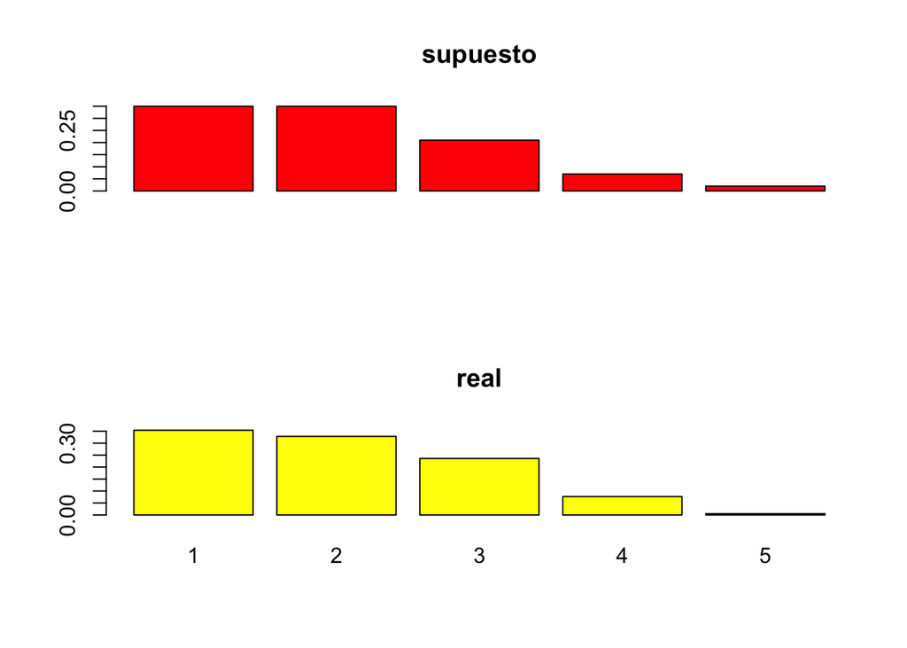

```r
par(mfrow=c(2,1))
barplot(c(.35,.35,.21,.07,.02), col="red", main='supuesto')
barplot(prop.table(tablaT),col="yellow", main='real')
```

## ANALIZANDO DOS VARIABLE

Aqui necesitamos la tabla de contingencias:

```r
tablaTE=table(ide12$TAMANO,ide12$eduOrd)
prop.table(tablaTE)
```

```
##
##            bajo       medio        alto
##   1 0.020512821 0.138461538 0.194871795
##   2 0.056410256 0.128205128 0.143589744
##   3 0.015384615 0.071794872 0.148717949
##   4 0.000000000 0.005128205 0.071794872
##   5 0.000000000 0.000000000 0.005128205
```

Luego, con la prueba Chi-Cuadrado se pregunta si el comportamiento conjunto expresa asoción:

```r
chisq.test(tablaTE)
```

```
##
##  Pearson's Chi-squared test
##
## data:  tablaTE
## X-squared = 18.042, df = 8, p-value = 0.02092
```

Se ha obtenido un resultado no confiable, pues algun requisito de la prueba no se puede sostener (hay celdas menores que 5, y hasta un cero). Lo bueno es que R alerta que podria ser incorrecto, y nos da una salida no paramétrica:

```r
chisq.test(tablaTE,simulate.p.value = T)
```

```
##
##  Pearson's Chi-squared test with simulated p-value (based on 2000
##  replicates)
##
## data:  tablaTE
## X-squared = 18.042, df = NA, p-value = 0.03198
```

Si el valor del **p-value** es menor a **0.05**, se asume que hay asociación (formalmente estamos rechanzando la hipotesis nula: “la variables son independientes”).

Hasta aqui sabemos que las variables están relacionadas, pero no tenemos mayor detalle de cómo es esa relación. Es aquí donde aparece el **análisis de correspondencias**. Éste es un análisis gráfico que permite conocer como se están asociando las categorías.

Se comienza por calcular la tabla de correspondencias, a partir de la tabla de contingencia:

```r
library(ca)
tablaCA_te=ca(tablaTE)
```

Este objeto tiene información interesante:

```r
tablaCA_te
```

```
##
##  Principal inertias (eigenvalues):
##            1        2
## Value      0.078998 0.013523
## Percentage 85.38%   14.62%
##
##
##  Rows:
##                 1         2         3         4         5
## Mass     0.353846  0.328205  0.235897  0.076923  0.005128
## ChiDist  0.140414  0.321618  0.142240  0.746443  0.879049
## Inertia  0.006976  0.033949  0.004773  0.042860  0.003963
## Dim. 1  -0.063547  1.081488 -0.505903 -2.572733 -2.967917
## Dim. 2   1.197668 -0.903582  0.031782 -1.592507 -2.384260
##
##
##  Columns:
##              bajo    medio      alto
## Mass     0.092308 0.343590  0.564103
## ChiDist  0.628641 0.266736  0.236666
## Inertia  0.036479 0.024446  0.031596
## Dim. 1   2.001206 0.831911 -0.834179
## Dim. 2  -2.414230 1.103799 -0.277258
```

Si revisamos los **eigenvalues** vemos que la tabla se ha descompuesto en dos dimensiones, y que la primera recoge la mayor información:

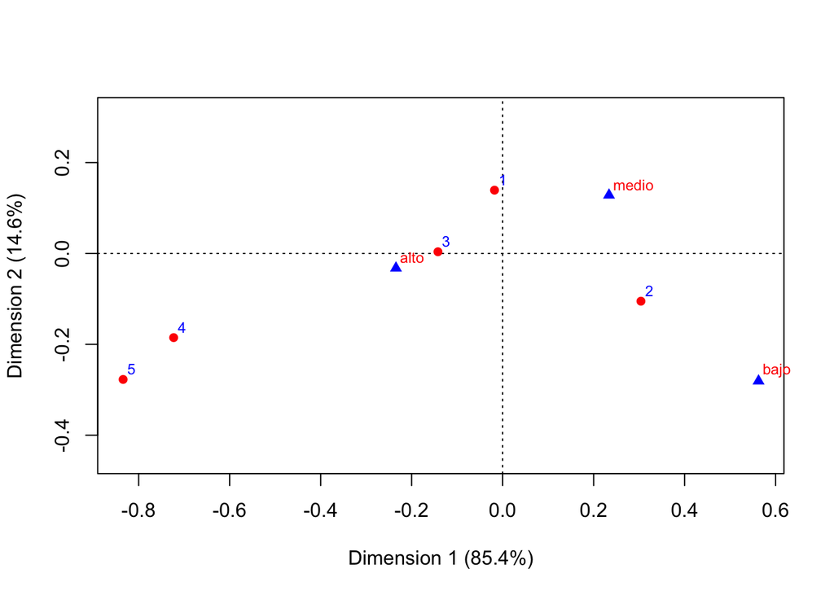

```r
plot.ca(tablaCA_te, col=c("red","blue"))
```

Queremos entender la relación entre las categorias de ambas variables. Para ello: 1. Debemos descartar las categorias cercanas al origen:

- “alto” y “3” están cerca al origen. Solo podemos concluir que no están asociadas.
2. Miremos las categorias distanciadas del origen:
- “medio” y “2” están relativamente más lejos, debe haber una ligera asociación. Como el ángulo entre ellas desde el origen es menor a 90, la asociación es positiva.
- “bajo” y ‘4’ y ‘5’ están muy distanciadas del origen. El angulo entre ellas es mayor que 90, lo que sugiere una asociación negativa.
- “bajo” está muy distanciada del origen, y ‘2’ no tanto. Si ‘2’ estuviese más cerca a ‘bajo’ sugeriría una asociación positiva fuerte.

Para ver los angulos podemos pedir:

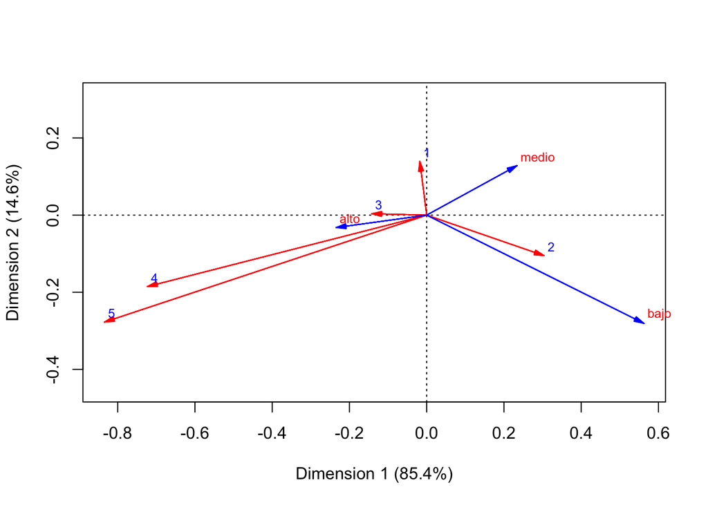

```r
plot.ca(tablaCA_te, col=c("red","blue"), arrows = c(T,T))
```

Inicio

#### [VOLVER AL SILABO](https://inteligenciaperu.github.io/Estadistica/)